# U.S.E. PhDs Job Market Workshop

Jacopo Mazza

Utrecht School of Economics

February 16, 2026

## Job markets, plural

- Government jobs
- Private sector / Tech / Data Science
- Non-academic research (think tanks, IOs, central banks)
- Academic research

## So What is This Job Market?

Standardized hiring system, coordinated around:

- Timing
- Applications
- Staging

## The Job Market Timeline

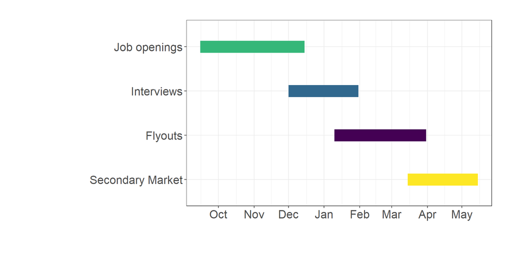

## I want to go on the market, now what?

- By end of September:
  - Have Job Market Paper ready;
  - Personal website up and running (GitHub Pages, Quarto, Hugo);
  - Register on [EconJobMarket.org](https://econjobmarket.org) and [JOE Network](https://www.aeaweb.org/joe/);
  - Ask for reference letters;
- By end of November:
  - Have presented your JMP multiple times (internal seminars, nearby departments, conferences)

## Job Openings: where

- [Econjobmarket](https://econjobmarket.org) 🌍
- [Job Openings for Economists (JOE)](https://www.aeaweb.org/joe/listings) 🌍
- [Inomics](https://inomics.com/) 🇪🇺
- [Academictransfer](https://www.academictransfer.com/en/) 🇳🇱
- [jobs.ac.uk](https://www.jobs.ac.uk/search/economics) 🇬🇧
- [AEA EconTrack](https://www.aeaweb.org/econtrack) (track who is interviewing)
- X / Bluesky / LinkedIn

## Job Openings: when

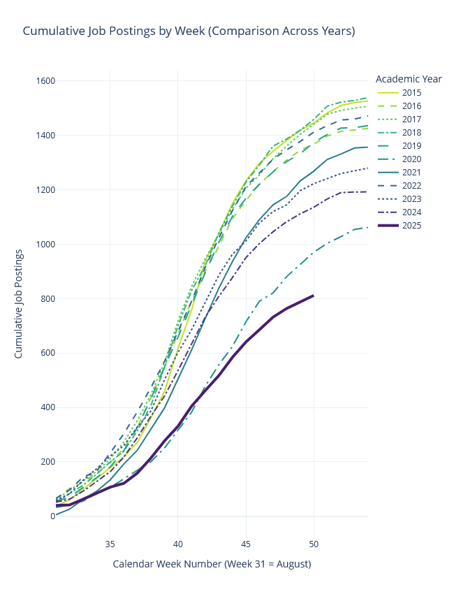

*Source: [Paul Goldsmith-Pinkham’s JOE Tracker](https://paulgp.com/2025/12/10/quick-update.html) — data & code on [GitHub](https://github.com/paulgp/joe-tracker)*

## Recent Trends: A Tighter Market

*Sources: [Goldsmith-Pinkham](https://paulgp.com/2025/11/24/joe-market-update-november.html); [Cawley (2025)](https://www.aeaweb.org/articles?id=10.1257/pandp.115.880)*

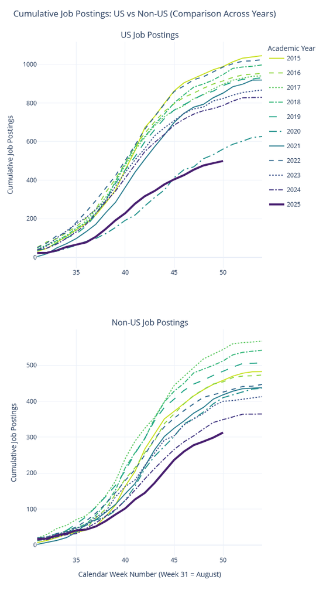

## Job Applications: How many?

[figure not shown]

*Source: [AEA webinar on job market](https://www.aeaweb.org/joe/communications/video/2021/webinar-part-1); see also [Cawley (2025)](https://www.aeaweb.org/articles?id=10.1257/pandp.115.880) for recent data*

## My Job Market

[figure not shown]

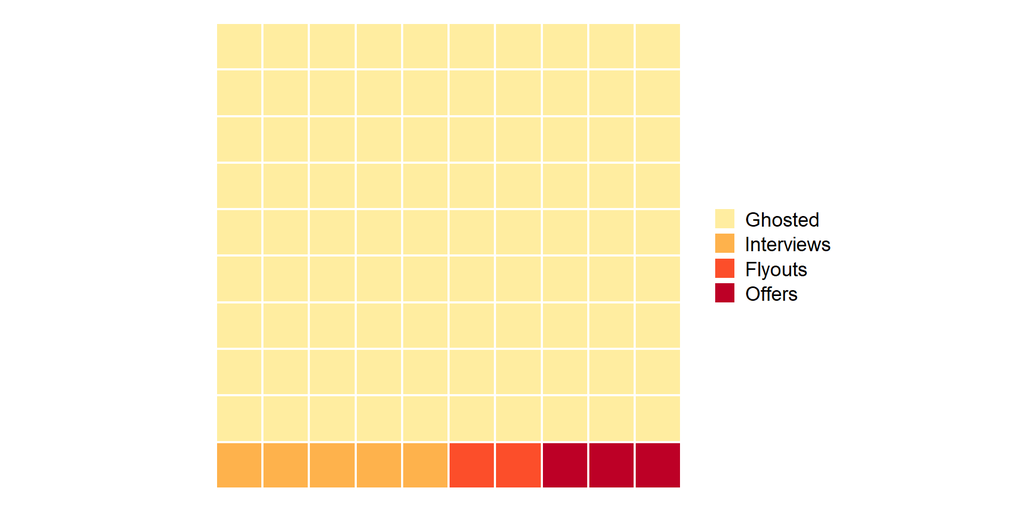

## Interviews

- **Format**
- **Expect**
- **Prepare**
- Virtual (Zoom). The AEA now recommends this as standard practice.
- 30 minutes.
- 2/3 members of hiring institution.
- 10/15 minutes pitch of job market paper (JMP);
- Questions about fit;
- Questions about your future research avenues;
- Space for your questions about the Demand Side.
- Short and effective presentation of your JMP;
- Check profiles of department. Who could you work with? Why?
- Think about your future research agenda;
- *Always* ask questions to hiring committee.

## Flyouts

- Format
- Expect
- Prepare
- 1-2 days visit on site (campus);
- Many 30-minute chats with members of staff;
- 1-1,5 hour seminar of JMP;
- Lunch and/or dinner with members of staff;
- Sometimes formal interview.
- Probing questions during seminar;
- Seminar usually attended by many members of staff with different background;
- Know ins and outs of your JMP;
- Answers to most obvious questions:
  - Your instrument is endogenous
  - External validity of your experiment
  - Using DiD? Oh boy…
- Work hard on the first 10 minutes of the presentation. Ideally, you need to entice all members of staff.
- Questions for other members of staff: check what they work on.

## The European Market (EJME)

**Timing** (fixed through 2028):

- Virtual interviews: mid-December (Dec 14-17, 2026 for your cohort)
- Flyouts: January-March (some UK/Belgian depts host multiple candidates on fixed dates)
- Offers: no deadline earlier than Feb 1; exploding offers (<7 days) are unacceptable

**How it differs from the US market** ([Schindler](https://david-schindler.de/guideejm/)):

- European depts have large within-department quality variation across fields. Compare faculty *in your area*, not department rankings.
- Cover letters matter more. Departments worry you are not genuinely interested. Customize, even if just one or two sentences.
- Networks matter. Ask your supervisors to contact colleagues at departments you applied to.

**Resources:**

- [EJME Candidate Directory](https://www.europeanjobmarketofeconomists.org/) + signaling mechanism (up to 10 signals)
- [EJME workshops](https://www.europeanjobmarketofeconomists.org/workshops): free sessions on interviews, flyouts, negotiating offers
- [EJME mock interviews](https://www.europeanjobmarketofeconomists.org/) for candidates whose departments do not offer them
- [Carlana guide for European candidates (EEA)](https://www.europeanjobmarketofeconomists.org/uploads/Job-Market-Guide-EEA-Website-Michela-Carlana-with-EAYE-Interventions.pdf)

## The Application Package

- The Job Market Paper
- CV
- Letters of Recommendation
- Cover Letter
- Miscellaneous
- The most important piece of your application;
- Generally single-authored (increasingly co-authored; if so, clearly signal your contribution);
- Showcases your best effort;
- Recommendations:
  - Work on your introduction again, and again, and again…and then some more.
  - Ask for feedback on it from anyone you can.
- Recommendations:
  - Pick a clear, clean template, no matter what format (e.g. .tex/.doc/.rmd).
  - Ask someone to go through it to check for clarity.
  - Carefully select the information to include.
  - Go for relevance, not length.
- Generally 2/3
- Your main advisor is expected to be one of them
- Only academic referees
- Recommendations:
  - Give ample time to letter writers
  - Ask people who know your work well
  - If you can, get a letter from someone outside U.S.E.
- 1-page letter where you substantiate your interest in the position
- Arguably **not** the most important piece of the package
- Recommendations:
  - Do not repeat the CV
  - Fine to have a standard template (but please change Institution and recipient’s names)
  - Tailor only when you have something specific to say about that specific application
- Course evaluations
- Research statement
- Teaching statement
- Diversity statement (increasingly requested, especially by US institutions)

## Some Tips

- Discuss the implications of going on the market with your partner.
- Seriously think through the implications of going on the market.
- Talk to recent graduates from U.S.E. who went through the market.
- Consider a dual strategy: both US/international and European markets (EJME + ASSA cycles overlap but are manageable).
- The market can be brutal. Look after yourself and let others do the same.
- The market can also be exhilarating!
- Do not let it define your worth.
- Check with us about what we can do for you!

## Useful Resources

- [Paul Goldsmith-Pinkham’s JOE Tracker (2015-2025)](https://paulgp.com/2025/12/10/quick-update.html) — the best current data source
- [Cawley (2025), “Report of the Committee on the Job Market,” AEA P&P](https://www.aeaweb.org/articles?id=10.1257/pandp.115.880)
- [Cawley’s Guide to the Job Market (updated 2025)](https://papers.ssrn.com/sol3/papers.cfm?abstract_id=2883489)
- [AEA Guidance on the 2025/26 Job Cycle](https://www.aeaweb.org/news/guidance-25-26-job-market-sept-2-2025)
- [AEA EconTrack](https://www.aeaweb.org/econtrack) — track interview and flyout invitations in real time
- [EJME 2025/26](https://www.europeanjobmarketofeconomists.org/) — European Job Market dates and guidelines
- [EJME workshops](https://www.europeanjobmarketofeconomists.org/workshops) — free sessions on interviews, flyouts, offers
- [Carlana guide for European candidates (EEA)](https://www.europeanjobmarketofeconomists.org/uploads/Job-Market-Guide-EEA-Website-Michela-Carlana-with-EAYE-Interventions.pdf)
- [EJME Mental Health Resources](https://sites.google.com/view/ejm-mentalhealth/references-and-links?authuser=0)
- [David Schindler guide for the European market](https://david-schindler.de/guideejm/)
- [Alex Albright’s blog on the Job Market](https://thelittledataset.com/2022/03/21/job-mkt/)
- [Job Market application tracker](https://github.com/benjaminvatterj/JobMarketTracker)
- [USE Job Market tips](https://intranet.uu.nl/en/knowledgebase/an-academic-career-after-use-some-tips)